# R Notebook

Estrutura do artigo a ser escrito ao final do curso de machine leaning:

Abstract

Introdução - Vender o artigo (motivar, falar sobre a relevância, convencer) - Sintética ou Autocontida - Sintética é aquela pequena que vai direto ao ponto e normalente tem 2 a 3 páginas. - Autocontida é aquela mais longa que normalmente tem mais de 5 páginas. Fala um pouco de tudo que contém no artigo.

Revisão bibliográfica - 1 parágrafo, 1 tópico e ao fim, um “fecho”.

Dados - descrever sua base de dados; - descrição, método de coleta; - análise exploratória de dados (mostrar os dados para o leitor atraves de tabelas, gráficos, mapas, prints, etc);

Metodologia - qual o paradigma você está utilizando (supervisionado, nmão supervisionado e semi-supervisionado); - especificar o algoritimo que será utilizado;

Resultados - Discussão - Mostrar resultados das performances dos diferentes algoritimos;

Conclusões

Referencias

Aqui começa um estudo sobre as aulas que do professor

```r
table(credit$bad_credit)
```

```
  0   1
710 302
```

Criação de boxplots

Um box plot

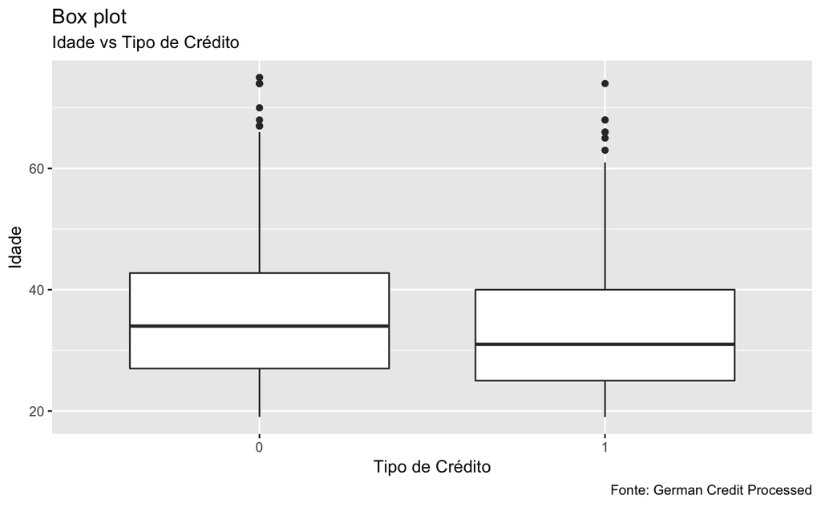

Vários box plots (com várias variáveis do banco de dados)

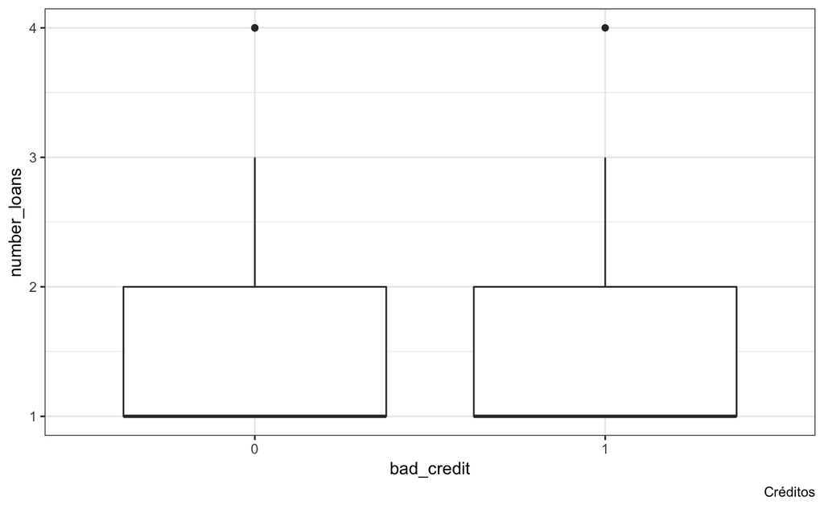

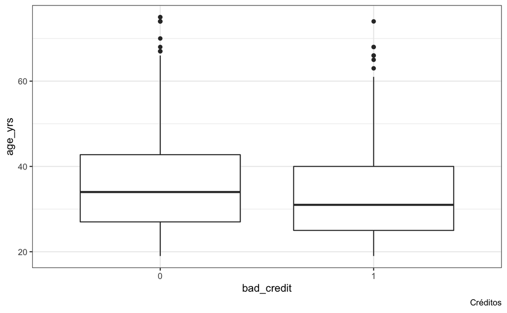

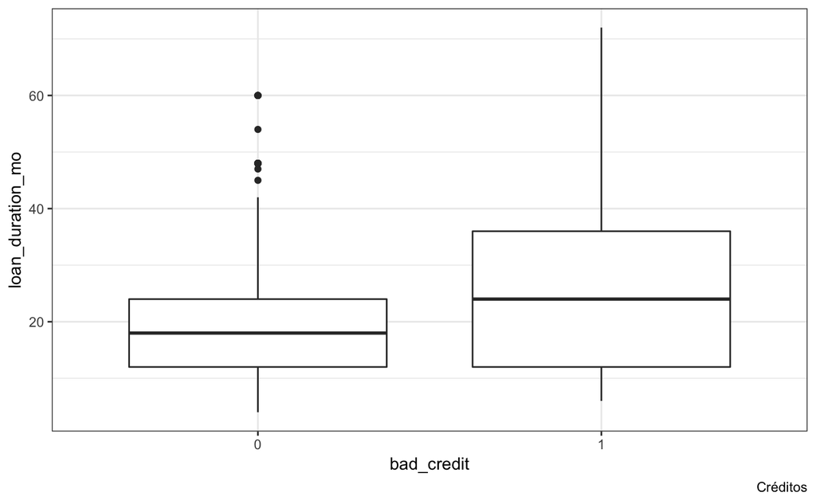

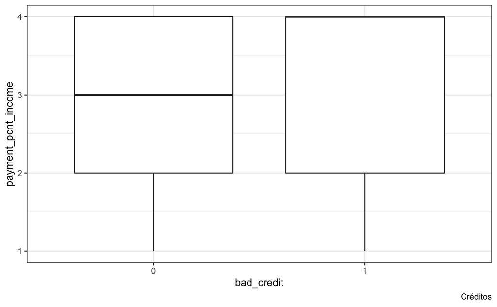

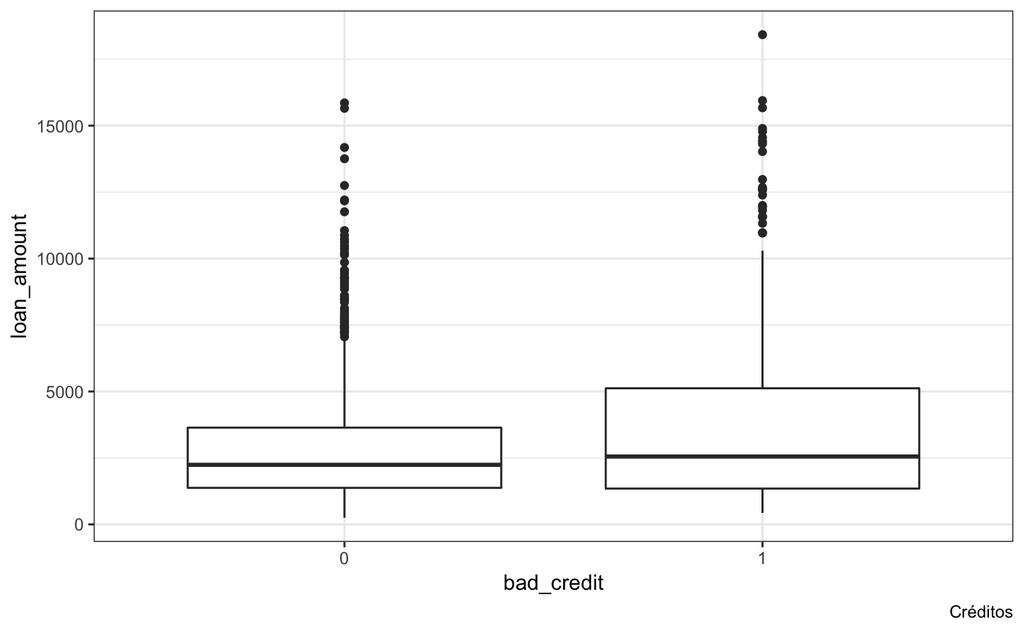

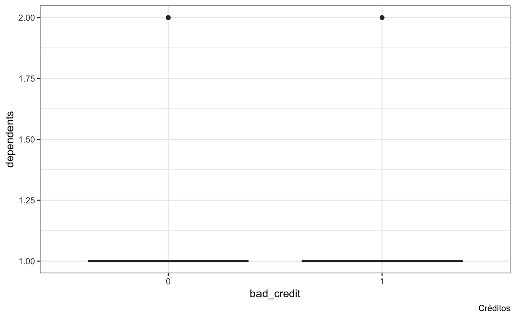

Criação de violins (grafico)

```r
ggplot(credit, aes(bad_credit, dependents)) +
  geom_violin() +
  labs(title = "Violin",
       subtitle = "Tipo de crédito vs Dependentes",
       x = "Tipo de Crédito",
       y = "Dependentes",
       caption = "Créditos:") +
  theme_dark()
```

[output not shown]

Vários graficos de Violin (com várias variáveis do banco de dados)

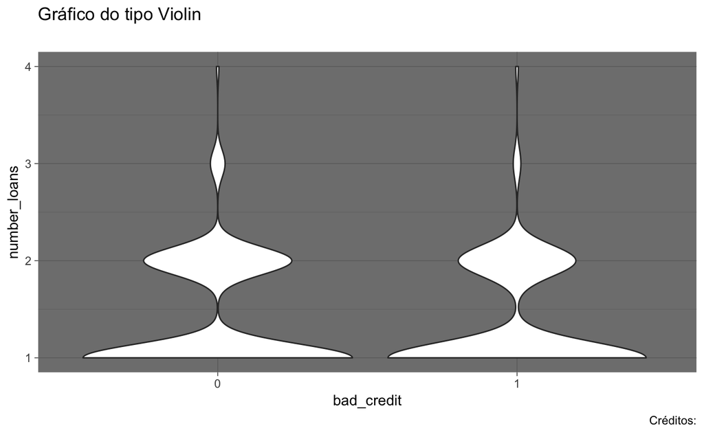

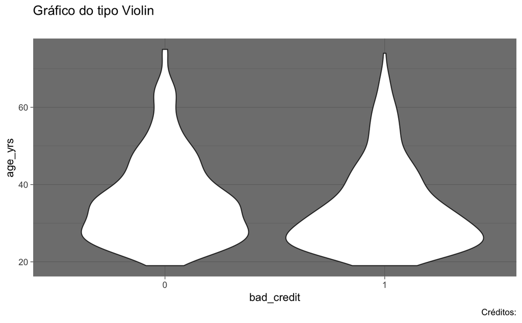

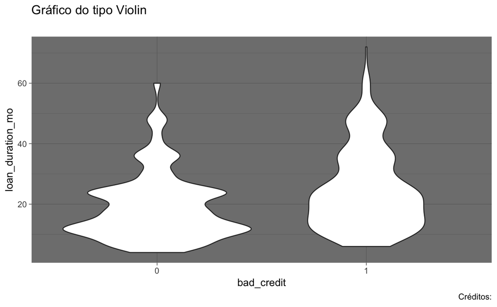

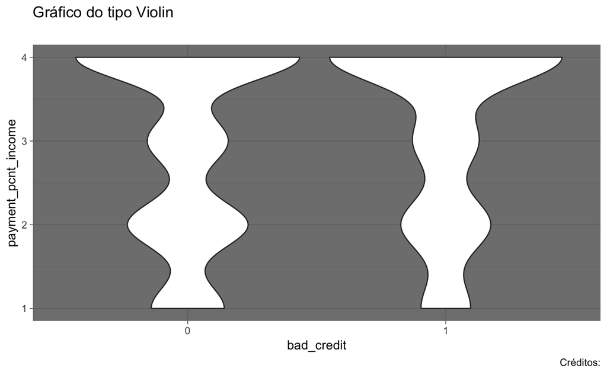

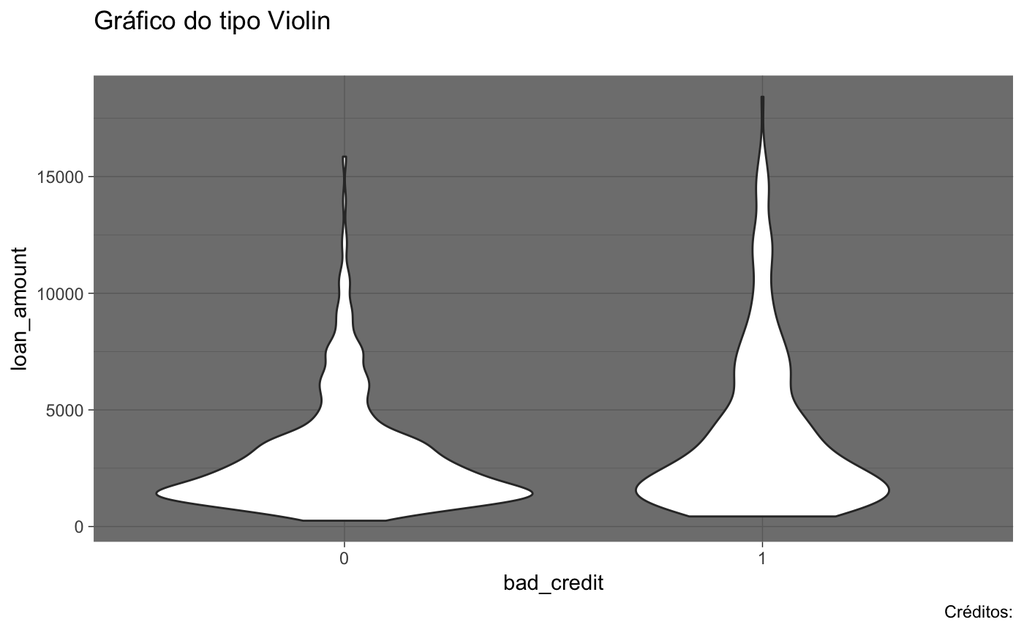

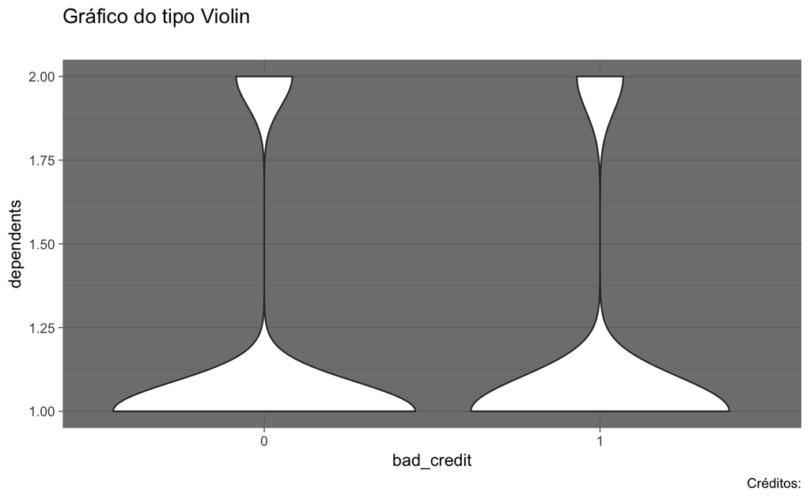